# JGipson Live Session Unit 3 Assignment

Johnny Gipson

September 15, 2018

# Questions 1: Github Cloning

Git Bash was used and the following code was to create and new directory, navigate, and clone the gut hub Repository

Git bash code:

pwd

mkdir JohnnyGipson

cd JohnnyGipson

git clone https://github.com/caesar0301/awesome-public-datasets

# Question 2a: Read Titantic Data Set and Create Data Frame

```r
Ship <-read.csv(file='C:/Users/Johnny Gipson/Desktop/titanic.csv', header=TRUE)
class (Ship)
```

```
## [1] "data.frame"
```

```r
dim (Ship)
```

```
## [1] 891  12
```

```r
names (Ship)
```

```
##  [1] "PassengerId" "Survived"    "Pclass"      "Name"        "Sex"
##  [6] "Age"         "SibSp"       "Parch"       "Ticket"      "Fare"
## [11] "Cabin"       "Embarked"
```

# Question 2b: Frequency Plot of Male and Female

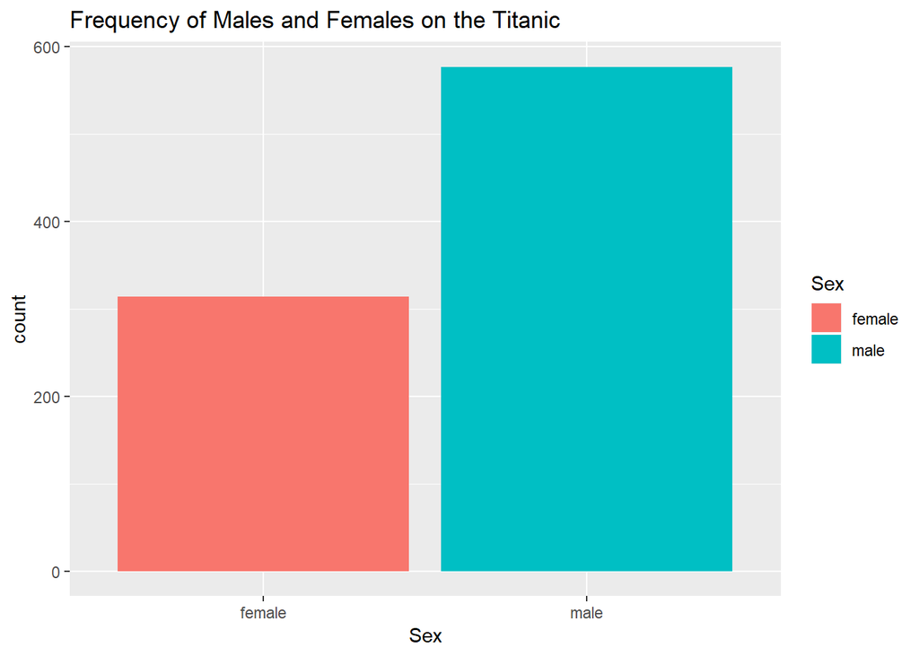

```r
library ("ggplot2")
Shipfreq <-ggplot (Ship) + geom_bar(aes(x=Sex, fill = Sex))
Shipfreq + ggtitle ("Frequency of Males and Females on the Titanic")
```

# Question 2c: Use one of apply functions to get the means of Age, Fare, Survival

```r
lapply (Ship["Age"], mean, na.rm=TRUE)
```

```
## $Age
## [1] 29.69912
```

```r
lapply (Ship["Fare"], mean, na.rm=TRUE)
```

```
## $Fare
## [1] 32.20421
```

```r
lapply (Ship["Survived"], mean, na.rm=TRUE)
```

```
## $Survived
## [1] 0.3838384
```

# Question 3a - Create Objects for median age, Min and Max Duration of Sleep, Mean and Standard Deviation of RSESS

```r
sleep <-read.csv(file='C:/Users/Johnny Gipson/Desktop/sleep_data_01.csv', header=TRUE)
class(sleep)
```

```
## [1] "data.frame"
```

```r
dim (sleep)
```

```
## [1] 101  15
```

```r
names (sleep)
```

```
##  [1] "SubjID"   "Age"      "Gender"   "PSQI"     "PSAScog"  "FOMO"
##  [7] "SMUISa"   "SM1"      "SM2"      "HADSa"    "HADSd"    "RSES"
## [13] "Bedtime"  "Latency"  "Duration"
```

```r
MedAge <-function(x) { median(x,na.rm=TRUE)}
MedAge(sleep$Age)
```

```
## [1] 14
```

```r
MinDuration <-function (x) {min(x,na.rm=TRUE)}
MinDuration (sleep$Duration)
```

```
## [1] 4
```

```r
MaxDuration <-function (x) {max(x,na.rm=TRUE)}
MaxDuration (sleep$Duration)
```

```
## [1] 11
```

```r
MEANRSES <-function(x) {mean(x,na.rm=TRUE)}
MEANRSES(sleep$RSES)
```

```
## [1] 18.11494
```

```r
SDRSES <-function(x) {sd(x,na.rm=TRUE)}
SDRSES(sleep$RSES)
```

```
## [1] 6.176522
```

## Question 3b - Create Data Frame with New Objects

```r
sleepa<-function (x) {data.frame("medianage"= MedAge(sleep$Age),"RSESMean"= MEANRSES(sleep$RSES)/5,"SDRSES"=SDRSES(sleep$RSES)/5, "RangeofDuration"= (MaxDuration(sleep$Duration)-MinDuration(sleep$Duration)))}
report<-sleepa(sleep)
report
```

```
##   medianage RSESMean   SDRSES RangeofDuration
## 1        14 3.622989 1.235304               7
```

## Question 3c - Change column names of dataframe

```r
library(data.table)
chgname <- function(x) {setnames(x, old=c("medianage","RSESMean","SDRSES","RangeofDuration"), new=c("MedianAge","SelfEsteem","SE_SD","DurationRange"))}
chgname(report)
report
```

```
##   MedianAge SelfEsteem    SE_SD DurationRange
## 1        14   3.622989 1.235304             7
```

## Question 3d - Round the Report to 2 digits

```r
rreport <-function(x) {round(x,2)}
rreport(report)
```

```
##   MedianAge SelfEsteem SE_SD DurationRange
## 1        14       3.62  1.24             7
```

## Questions 3e: Run function on your sleep Data

```r
sleep <-read.csv(file='C:/Users/Johnny Gipson/Desktop/sleep_data_01.csv', header=TRUE)
class(sleep)
```

```
## [1] "data.frame"
```

```r
dim (sleep)
```

```
## [1] 101  15
```

```r
names (sleep)
```

```
##  [1] "SubjID"   "Age"      "Gender"   "PSQI"     "PSAScog"  "FOMO"
##  [7] "SMUISa"   "SM1"      "SM2"      "HADSa"    "HADSd"    "RSES"
## [13] "Bedtime"  "Latency"  "Duration"
```

```r
MedAge <-function(x) { median(x,na.rm=TRUE)}
MedAge(sleep$Age)
```

```
## [1] 14
```

```r
MinDuration <-function (x) {min(x,na.rm=TRUE)}
MinDuration (sleep$Duration)
```

```
## [1] 4
```

```r
MaxDuration <-function (x) {max(x,na.rm=TRUE)}
MaxDuration (sleep$Duration)
```

```
## [1] 11
```

```r
MEANRSES <-function(x) {mean(x,na.rm=TRUE)}
MEANRSES(sleep$RSES)
```

```
## [1] 18.11494
```

```r
SDRSES <-function(x) {sd(x,na.rm=TRUE)}
SDRSES(sleep$RSES)
```

```
## [1] 6.176522
```

```r
sleepa<-function (x) {data.frame("medianage"= MedAge(sleep$Age),"RSESMean"= MEANRSES(sleep$RSES)/5,"SDRSES"=SDRSES(sleep$RSES)/5, "RangeofDuration"= (MaxDuration(sleep$Duration)-MinDuration(sleep$Duration)))}
report<-sleepa(sleep)
report
```

```
##   medianage RSESMean   SDRSES RangeofDuration
## 1        14 3.622989 1.235304               7
```

```r
library(data.table)
chgname <- function(x) {setnames(x, old=c("medianage","RSESMean","SDRSES","RangeofDuration"), new=c("MedianAge","SelfEsteem","SE_SD","DurationRange"))}
chgname(report)
report
```

```
##   MedianAge SelfEsteem    SE_SD DurationRange
## 1        14   3.622989 1.235304             7
```

```r
rreport <-function(x) {round(x,2)}
rreport(report)
```

```
##   MedianAge SelfEsteem SE_SD DurationRange
## 1        14       3.62  1.24             7
```

## Question 4a: Install the fivethirtyeight package

Code for install - install.packages(“fivethirtyeight”)

```r
library("fivethirtyeight")
```

## Question 4b:Assign the 22nd data set to an object ‘df’

```r
data(package="fivethirtyeight")
class(college_recent_grads)
```

```
## [1] "tbl_df"     "tbl"        "data.frame"
```

```r
df<-data.frame(college_recent_grads)
```

## Question 4C - URL to the related story

The first r code used to find the URL came back with a warning message that it could not be found. So a detail seach on the entire list was made to the URL. The URL to the college recent data is http://fivethirtyeight.com/features/the-economic-guide-to-picking-a-college-major/

```r
vignette("college_recent_grads", package = "fivethirtyeight")
```

```
## Warning: vignette 'college_recent_grads' not found
```

```r
vignette("fivethirtyeight", package = "fivethirtyeight")
```

```
## starting httpd help server ... done
```

## Question 4D - Get the dimensions and column names of df

```r
dim(df)
```

```
## [1] 173  21
```

```r
colnames(df)
```

```
##  [1] "rank"                        "major_code"
##  [3] "major"                       "major_category"
##  [5] "total"                       "sample_size"
##  [7] "men"                         "women"
##  [9] "sharewomen"                  "employed"
## [11] "employed_fulltime"           "employed_parttime"
## [13] "employed_fulltime_yearround" "unemployed"
## [15] "unemployment_rate"           "p25th"
## [17] "median"                      "p75th"
## [19] "college_jobs"                "non_college_jobs"
## [21] "low_wage_jobs"
```

## Question 5a -Give column names and count the columns

```r
colnames(df)
```

```
##  [1] "rank"                        "major_code"
##  [3] "major"                       "major_category"
##  [5] "total"                       "sample_size"
##  [7] "men"                         "women"
##  [9] "sharewomen"                  "employed"
## [11] "employed_fulltime"           "employed_parttime"
## [13] "employed_fulltime_yearround" "unemployed"
## [15] "unemployment_rate"           "p25th"
## [17] "median"                      "p75th"
## [19] "college_jobs"                "non_college_jobs"
## [21] "low_wage_jobs"
```

```r
ncol(df)
```

```
## [1] 21
```

## Question 5b - Generate a count of each unique Major_category in a data frame

```r
library (plyr)
x<-count(df$major_category)
major_count<-as.data.frame(x, row.names=NULL)
class (major_count)
```

```
## [1] "data.frame"
```

```r
major_count
```

```
##                                      x freq
## 1      Agriculture & Natural Resources   10
## 2                                 Arts    8
## 3               Biology & Life Science   14
## 4                             Business   13
## 5          Communications & Journalism    4
## 6              Computers & Mathematics   11
## 7                            Education   16
## 8                          Engineering   29
## 9                               Health   12
## 10           Humanities & Liberal Arts   15
## 11 Industrial Arts & Consumer Services    7
## 12                   Interdisciplinary    1
## 13                 Law & Public Policy    5
## 14                   Physical Sciences   10
## 15            Psychology & Social Work    9
## 16                      Social Science    9
```

## Question 5c- Create barplot of frequency - to much great coding in ggplot to go to waste. Using barplot() is question 5c.1

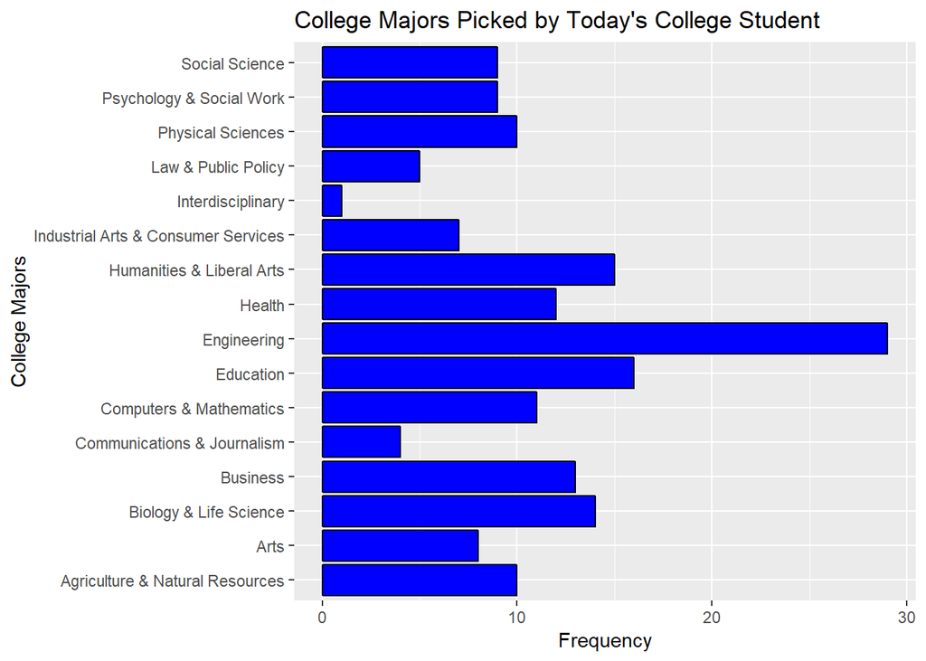

```r
library(gcookbook)
MC<-ggplot(major_count, aes(x=x,y=freq)) + geom_bar(stat="identity", fill="blue", colour="black")+coord_flip()
MC + ggtitle ("College Majors Picked by Today's College Student") + xlab("College Majors") +ylab ("Frequency")
```

## Question 5c.1- Create barplot of frequency using barplot()

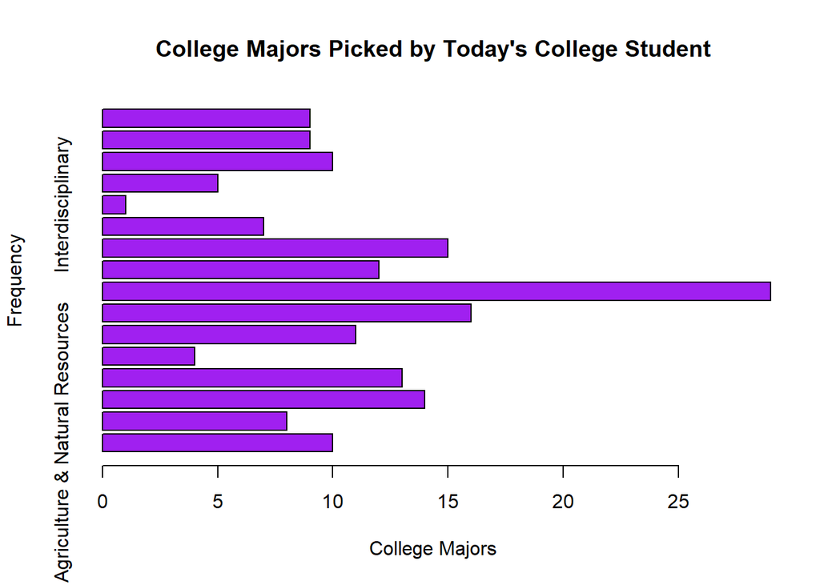

```r
par(las=2,barplot(major_count$freq, names.arg=major_count$x, horiz=TRUE,col="purple",main="College Majors Picked by Today's College Student", xlab="College Majors", ylab="Frequency" ))
```

## Question 5d -Write fivethirtyeight data to csv file

```r
write.csv(df,"C:/Users/Johnny Gipson/Desktop/college_recent_grads.csv",row.names=FALSE)
```

## Question 6 Link to my github repository

https://github.com/jlgipson/MSDS6306